# KSooklall_Homework15

Kenan Sooklall

5/8/2021

### Exercise 1

Find the equation of the regression line for the given points. Round any final values to the nearest hundredth, if necessary.

$points: ( 5.6, 8.8 ), ( 6.3, 12.4 ), ( 7, 14.8 ), ( 7.7, 18.2 ), ( 8.4, 20.8 )$

```r
df <- data.frame(x=c(5.6, 6.3,7,7.7,8.4), y=c(8.8,12.4,14.8,18.2,20.8))

df %>% mutate(x2 = x^2,
              y2 = y^2,
              xy = x * y,
              n = nrow(df),
              slope = (n*sum(xy) - sum(x)*sum(y))/(n*sum(x2) - sum(x)^2),
              intercept = mean(y) - slope * mean(x))
```

```
##     x    y    x2     y2     xy n    slope intercept
## 1 5.6  8.8 31.36  77.44  49.28 5 4.257143     -14.8
## 2 6.3 12.4 39.69 153.76  78.12 5 4.257143     -14.8
## 3 7.0 14.8 49.00 219.04 103.60 5 4.257143     -14.8
## 4 7.7 18.2 59.29 331.24 140.14 5 4.257143     -14.8
## 5 8.4 20.8 70.56 432.64 174.72 5 4.257143     -14.8
```

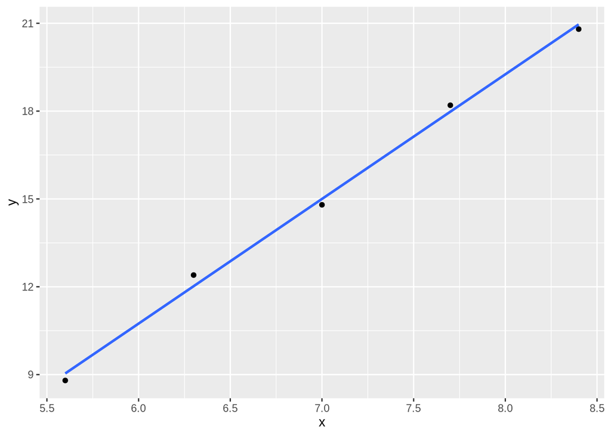

```r
df %>%
  ggplot(aes(x,y)) +
  geom_point() +
  geom_smooth(method='lm', se=F)
```

```r
ml = lm(y ~x, data=df)
summary(ml)
```

```
##
## Call:
## lm(formula = y ~ x, data = df)
##
## Residuals:
##     1     2     3     4     5
## -0.24  0.38 -0.20  0.22 -0.16
##
## Coefficients:
##             Estimate Std. Error t value Pr(>|t|)
## (Intercept) -14.8000     1.0365  -14.28 0.000744 ***
## x             4.2571     0.1466   29.04 8.97e-05 ***
## ---
## Signif. codes:  0 '***' 0.001 '**' 0.01 '*' 0.05 '.' 0.1 ' ' 1
##
## Residual standard error: 0.3246 on 3 degrees of freedom
## Multiple R-squared:  0.9965, Adjusted R-squared:  0.9953
## F-statistic: 843.1 on 1 and 3 DF,  p-value: 8.971e-05
```

$y = 4.26 * x - 14.80$

### Exercise 2

Find all local maxima, local minima, and saddle points for the function given below. Write your answer(s) in the form ( x, y, z ). Separate multiple points with a comma.

$$f(x,y) = 24x - 6xy^2 - 8y^3 \\ f_x = 24 - 6y^2 = 0 \rightarrow y=\pm2 \\ f_{xx} = 0 \\f_y = -12xy - 24y^2 =0 \rightarrow x=\pm4 \\ f_{yy} = -12x - 48y \\ f_{xy} = -12y\\ Critical-Points: (2, -4), (-2, 4) \\ D(x,y) = f_{xx} * f_{yy} - f_{xy}^2 = - 144y^2 \rightarrow D(x,y) < 0$$
Points (-4, 2) and (4, -2) are both saddle points

### Exercise 3

A grocery store sells two brands of a product, the “house” brand and a “name” brand. The manager estimates that if she sells the “house” brand for x dollars and the “name” brand for y dollars, she will be able to sell $81 - 21x + 17y$ units of the “house” brand and $40 + 11x - 23y$ units of the “name” brand.

Step 1. Find the revenue function R ( x, y ).

Step 2. What is the revenue if she sells the “house” brand for 2.30 and the “name” brand for 4.10?

$$R(x,y) = x*house+y*name = x*(81 - 21x + 17y) + y*(40 + 11x - 23y) \\R(2.3, 4.1) = 116.62$$

### Exercise 4

A company has a plant in Los Angeles and a plant in Denver. The firm is committed to produce a total of 96 units of a product each week. The total weekly cost is given by $C(x, y) = (1/6)x^2 + (1/6)y^2 + 7x + 25y + 700$, where x is the number of units produced in Los Angeles and y is the number of units produced in Denver. How many units should be produced in each plant to minimize the total weekly cost?

$$x + y = 96 \rightarrow x = 96 - y \\ C(x, y) = (1/6)x^2 + (1/6)y^2 + 7x + 25y + 700 \\ C(96-y,y) = (1/6)*(96-y)^2+(1/6)y^2+7(96-y) + 25y + 700 = (1/3)y^2 - 14y + 2908 \\dC/dy = (2/3)y - 14 = 0 \rightarrow y=21 \rightarrow x=75$$
75 units produced in Los Angeles

21 units produced in Denver.

### Exercise 5

Evaluate the double integral on the given region. Write your answer in exact form without decimals. $R: 2 x 4 , 2 y 4 $

$$\int_2^4{\int_2^4{e^{8x+3y}}} dydx = \int_2^4{(1/3){e^{8x+3y}}} |_2^4dx = \int_2^4{(1/3){e^{8x+6}(e^6-1)}} dx \\ \rightarrow(1/24)e^{8x+6}(e^6-1)|_2^4=(e^{44}-e^{38}-e^{28}+e^{22})/24$$